# M. bovis Genome Assembly Quality

Noah A. Legall

2/20/2020

# QUAST metric dictionary

## No. of contigs:

The total number of contigs in the assembly.

## Largest contig:

The length of the largest contig in the assembly.

## Total length:

The total number of bases in the assembly.

## Nx (where 0 x 100):

The largest contig length, L, such that using contigs of length. L accounts for at least x% of the bases of the assembly.

## NGx, Genome Nx:

The contig length such that using equal or longer length contigs produces x% of the length of the reference genome, rather than x% of the assembly length.

## No. of misassemblies:

The number of misassemblies, using Plantagora’s definition. Plantagora defines a misassembly breakpoint as a position in the assembled contigs where the left flanking sequence aligns over 1 kb away from the right flanking sequence on the reference, or they overlap by 41 kb, or the flanking sequences align on opposite strands or different chromosomes. QUAST also generates a report with the number of misassemblies because of each of these reasons. See the Supplementary Methods for details.

## No. of misassembled contigs:

The number of contigs that contain misassembly breakpoints.

## Misassembled contigs length:

The total number of bases contained in all contigs that have one or more misassemblies.

## No. of unaligned contigs:

The number of contigs that have no alignment to the reference sequence.

## No. of ambiguously mapped contigs:

The number of contigs that have high-scoring reference alignments of equal quality in multiple locations on the reference genome.

## Genome fraction (%):

The total number of aligned bases in the reference, divided by the genome size. A base in the reference genome is counted as aligned if at least one contig has at least one alignment to this base. Contigs from repeat regions may map to multiple places, and thus may be counted multiple times in this quantity.

## Duplication ratio:

The total number of aligned bases in the assembly i.e. total length minus unaligned contigs length), divided by the total number of aligned bases in the reference [see the genome fraction (%) metric]. If the assembly contains many contigs that cover the same regions of the reference, its duplication ratio may be much41. This may occur due to overestimating repeat multiplicities and due to small overlaps between contigs, among other reasons.

## GC (%):

The total number of G and C nucleotides in the assembly, divided by the total length of the assembly. This metric can be computed without a reference genome.

## No. of mismatches per 100 kb:

The average number of mismatches per 100 000 aligned bases. QUAST also generates a more detailed report with the coordinates of mismatches. This metric does not distinguish between single-nucleotide polymorphisms, which are true differences in the assembled genome versus the reference genome, and single-nucleotide errors, which are due to errors in reads or errors in the assembly algorithm.

## No. of indels per 100 kb:

The average number of single nucleotide insertions or deletions per 100 000 aligned bases. A detailed report with coordinates of indels for all assemblies is also available.

# SPAdes assembly summary statistics

```r
MI_assemb_stats <- read.csv("transposed_report.csv",header = TRUE)
summary(MI_assemb_stats)
```

```
##                                  Assembly   X..contigs.....0.bp.
##  00_17MIDNRdeerMontm_S23_L001.contigs:  1   Min.   :125.0
##  00_1MIDNRdeerAlc_S5_L001.contigs    :  1   1st Qu.:150.0
##  00_21MIDNRdeerOts_S14_L001.contigs  :  1   Median :162.0
##  00_26MIDNRdeerAlp_S12_L001.contigs  :  1   Mean   :179.6
##  00_27MIDNRdeerAlp_S27_L001.contigs  :  1   3rd Qu.:180.0
##  00_28MIDNRdeerEmm_S2_L001.contigs   :  1   Max.   :759.0
##  (Other)                             :119
##  X..contigs.....1000.bp. X..contigs.....5000.bp. X..contigs.....10000.bp.
##  Min.   : 81.0           Min.   : 56.0           Min.   : 54.00
##  1st Qu.: 99.0           1st Qu.: 73.0           1st Qu.: 69.00
##  Median :104.0           Median : 77.0           Median : 72.00
##  Mean   :106.8           Mean   : 78.3           Mean   : 72.87
##  3rd Qu.:110.0           3rd Qu.: 81.0           3rd Qu.: 75.00
##  Max.   :266.0           Max.   :178.0           Max.   :138.00
##
##  X..contigs.....25000.bp. X..contigs.....50000.bp. Total.length.....0.bp.
##  Min.   : 44.00           Min.   :14.00            Min.   : 4249421
##  1st Qu.: 49.00           1st Qu.:29.00            1st Qu.: 4305346
##  Median : 50.00           Median :30.00            Median : 4309691
##  Mean   : 51.28           Mean   :30.42            Mean   : 4383461
##  3rd Qu.: 52.00           3rd Qu.:31.00            3rd Qu.: 4314221
##  Max.   :112.00           Max.   :82.00            Max.   :13163095
##
##  Total.length.....1000.bp. Total.length.....5000.bp. Total.length.....10000.bp.
##  Min.   : 4183264          Min.   : 3950492          Min.   : 3612141
##  1st Qu.: 4278535          1st Qu.: 4218804          1st Qu.: 4174644
##  Median : 4283458          Median : 4227343          Median : 4188224
##  Mean   : 4351345          Mean   : 4292377          Mean   : 4252383
##  3rd Qu.: 4286059          3rd Qu.: 4232686          3rd Qu.: 4204881
##  Max.   :13091806          Max.   :12958417          Max.   :12878410
##
##  Total.length.....25000.bp. Total.length.....50000.bp.   X..contigs
##  Min.   : 2351377           Min.   :  961599           Min.   :100.0
##  1st Qu.: 3813408           1st Qu.: 3026891           1st Qu.:118.0
##  Median : 3857643           Median : 3079089           Median :127.0
##  Mean   : 3905724           Mean   : 3148140           Mean   :130.4
##  3rd Qu.: 3896247           3rd Qu.: 3200711           3rd Qu.:134.0
##  Max.   :12454187           Max.   :11407042           Max.   :303.0
##
```

[output cut: 65 more lines]

```
##  Min.   :4205859      98885  :  4   Min.   : 26462   42750  :  4
##  1st Qu.:4283547      69217  :  3   1st Qu.: 73993   42789  :  2
##  Median :4286534      79191  :  2   Median : 80239   43131  :  2
##  Mean   :4285427      80775  :  2   Mean   : 78283   44896  :  2
##  3rd Qu.:4289124      -      :  1   3rd Qu.: 81498   48325  :  2
##  Max.   :4300669      102672 :  1   Max.   :119671   -      :  1
##                       (Other):112                    (Other):112
##      NGA75            LA50        LGA50            LA75        LGA75
##  Min.   :14206   16     :32   Min.   :12.00   34     :19   Min.   : 27.00
##  1st Qu.:41255   17     :25   1st Qu.:16.00   33     :15   1st Qu.: 34.00
##  Median :42771   15     :22   Median :17.00   35     :15   Median : 35.00
##  Mean   :43352   18     :19   Mean   :17.07   32     :14   Mean   : 36.22
##  3rd Qu.:46463   19     : 9   3rd Qu.:18.00   36     :14   3rd Qu.: 38.00
##  Max.   :59033   14     : 8   Max.   :48.00   37     :14   Max.   :104.00
##                  (Other):10                   (Other):34
```

## Presence of outlier

There seems to be a clear outlier, 09_4305_S4_L001.contigs. let’s drop this row

```r
MI_assemb_stats <- MI_assemb_stats[MI_assemb_stats$Assembly != "09_4305_S4_L001.contigs",]
summary(MI_assemb_stats)
```

```
##                                  Assembly   X..contigs.....0.bp.
##  00_17MIDNRdeerMontm_S23_L001.contigs:  1   Min.   :125.0
##  00_1MIDNRdeerAlc_S5_L001.contigs    :  1   1st Qu.:150.0
##  00_21MIDNRdeerOts_S14_L001.contigs  :  1   Median :162.0
##  00_26MIDNRdeerAlp_S12_L001.contigs  :  1   Mean   :177.9
##  00_27MIDNRdeerAlp_S27_L001.contigs  :  1   3rd Qu.:179.2
##  00_28MIDNRdeerEmm_S2_L001.contigs   :  1   Max.   :759.0
##  (Other)                             :118
##  X..contigs.....1000.bp. X..contigs.....5000.bp. X..contigs.....10000.bp.
##  Min.   : 81             Min.   : 56.00          Min.   : 54.00
##  1st Qu.: 99             1st Qu.: 72.75          1st Qu.: 69.00
##  Median :104             Median : 77.00          Median : 72.00
##  Mean   :106             Mean   : 77.73          Mean   : 72.35
##  3rd Qu.:110             3rd Qu.: 81.00          3rd Qu.: 75.00
##  Max.   :266             Max.   :178.00          Max.   :131.00
##
##  X..contigs.....25000.bp. X..contigs.....50000.bp. Total.length.....0.bp.
##  Min.   :44.00            Min.   :14               Min.   :4249421
##  1st Qu.:49.00            1st Qu.:29               1st Qu.:4305305
##  Median :50.00            Median :30               Median :4309614
##  Mean   :50.79            Mean   :30               Mean   :4312657
##  3rd Qu.:52.00            3rd Qu.:31               3rd Qu.:4313837
##  Max.   :61.00            Max.   :35               Max.   :4603690
##
##  Total.length.....1000.bp. Total.length.....5000.bp. Total.length.....10000.bp.
##  Min.   :4183264           Min.   :3950492           Min.   :3612141
##  1st Qu.:4278533           1st Qu.:4218747           1st Qu.:4174478
##  Median :4283354           Median :4227234           Median :4187922
##  Mean   :4280858           Mean   :4222490           Mean   :4182818
##  3rd Qu.:4286058           3rd Qu.:4232558           3rd Qu.:4204738
##  Max.   :4297093           Max.   :4251439           Max.   :4243443
##
##  Total.length.....25000.bp. Total.length.....50000.bp.   X..contigs
##  Min.   :2351377            Min.   : 961599            Min.   :100.0
##  1st Qu.:3813023            1st Qu.:3024258            1st Qu.:118.0
##  Median :3856946            Median :3078356            Median :126.5
##  Mean   :3836785            Mean   :3081536            Mean   :129.3
##  3rd Qu.:3895052            3rd Qu.:3192889            3rd Qu.:134.0
##  Max.   :4100061            Max.   :3595013            Max.   :303.0
##
```

[output cut: 65 more lines]

```
##  Min.   :4205859      98885  :  4   Min.   : 26462   42750  :  4
##  1st Qu.:4283527      69217  :  3   1st Qu.: 74002   42789  :  2
##  Median :4286498      79191  :  2   Median : 80282   43131  :  2
##  Mean   :4285342      80775  :  2   Mean   : 78361   44896  :  2
##  3rd Qu.:4289103      102672 :  1   3rd Qu.: 81521   48325  :  2
##  Max.   :4300669      103202 :  1   Max.   :119671   15070  :  1
##                       (Other):111                    (Other):111
##      NGA75            LA50        LGA50            LA75        LGA75
##  Min.   :14206   16     :32   Min.   :12.00   34     :19   Min.   : 27.00
##  1st Qu.:41255   17     :25   1st Qu.:16.00   33     :15   1st Qu.: 33.75
##  Median :42771   15     :22   Median :17.00   35     :15   Median : 35.00
##  Mean   :43342   18     :19   Mean   :17.07   32     :14   Mean   : 36.23
##  3rd Qu.:46793   19     : 9   3rd Qu.:18.00   36     :14   3rd Qu.: 38.00
##  Max.   :59033   14     : 8   Max.   :48.00   37     :14   Max.   :104.00
##                  (Other): 9                   (Other):33
```

I feel more confident because now all the genome lengths vary between 4.2 - 4.4 million bp. These values are about the size of the M. bovis reference genome.

# Data Exploration

## Distribution of the statistics QUAST outputs

Visualize how the histograms compare to released numbers of M. bovis genome assembly statisitics. These are the comparable values from (Branger et al., 2017)

```r
total_length <- 4296059
total_contigs <- 146
largest_contigs <- 237066
gc_content <- 65.54
n50 <- 98742
```

## Key distributions for genome assembly Quality

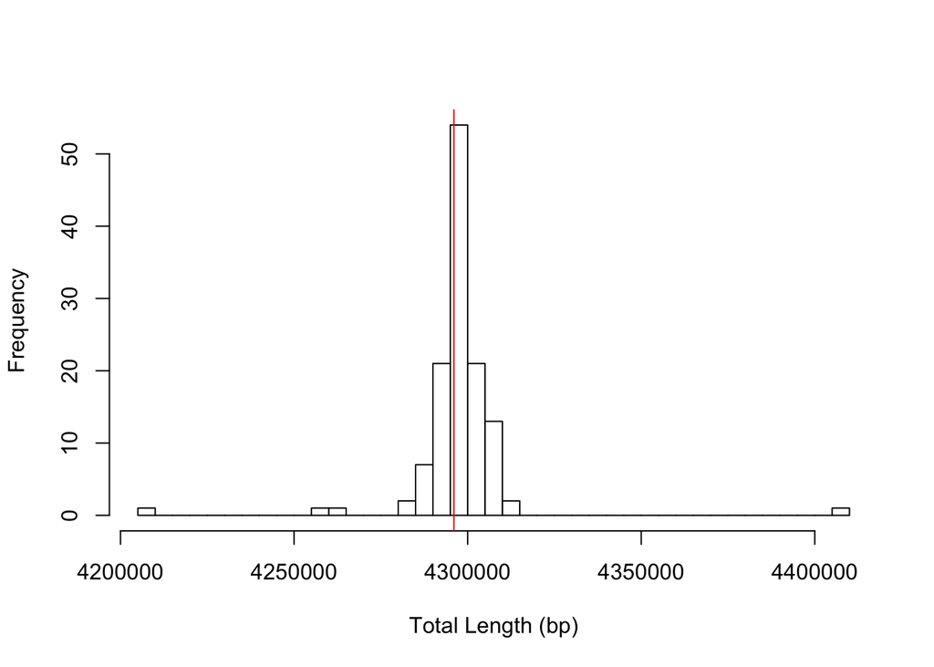

```r
hist(MI_assemb_stats$Total.length, main = "", xlab = "Total Length (bp)",breaks = 50)
abline(v=total_length,col="red")
```

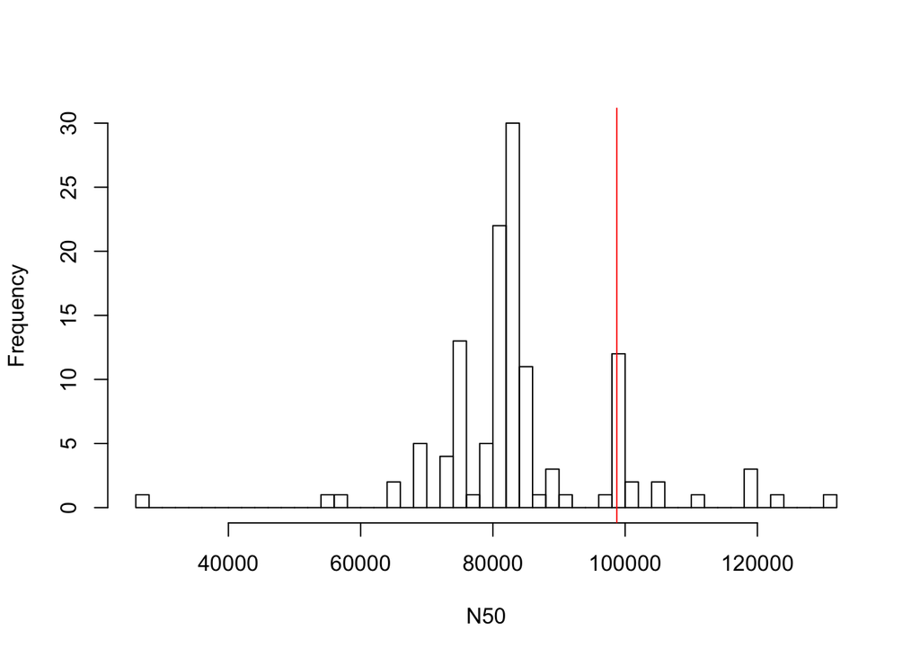

```r
hist(MI_assemb_stats$N50, main = "", xlab = "N50", breaks = 50)
abline(v=n50,col="red")
```

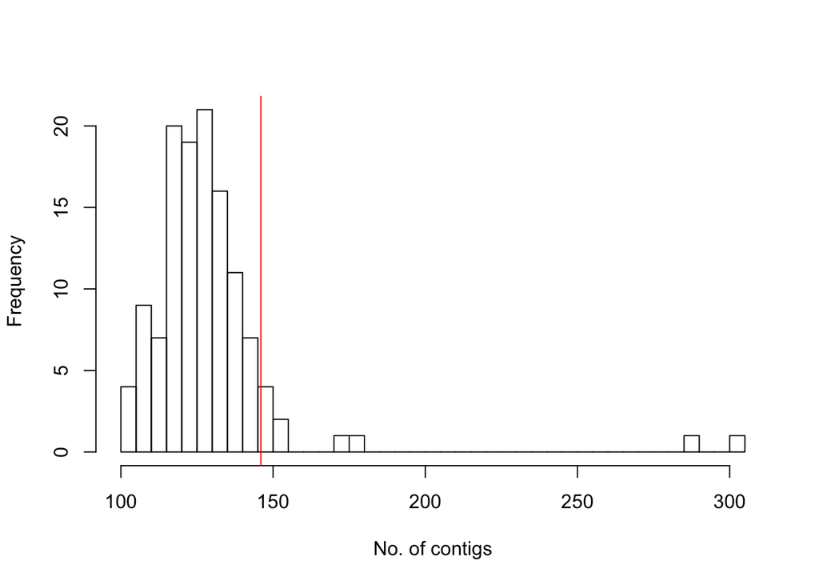

```r
hist(MI_assemb_stats$X..contigs, main = "", xlab = "No. of contigs",breaks = 50)
abline(v=total_contigs,col="red")
```

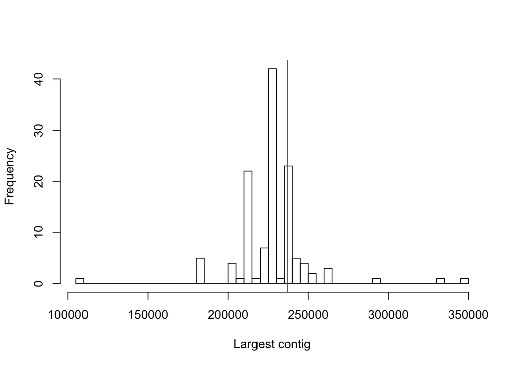

```r
hist(MI_assemb_stats$Largest.contig, main = "", xlab = "Largest contig",breaks = 50)
abline(v=largest_contigs,col="red")
```

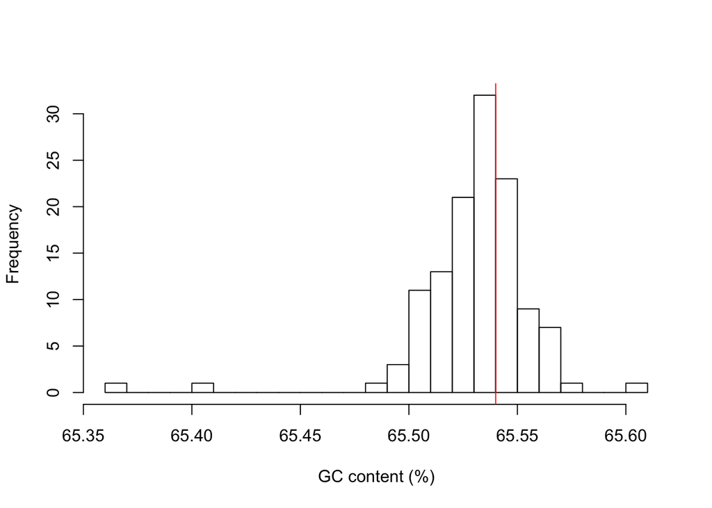

```r
hist(MI_assemb_stats$GC...., main = "", xlab = "GC content (%)",breaks = 25)
abline(v=gc_content,col="red")
```